# Introduction to Euler’s Method

March, 2025

## What is Euler’s Method?

- A simple, numerical procedure for solving differential equations.
- Approximates solutions by taking small, finite steps along the path of the solution.
- Relies on the concept of the slope or rate of change at a given point.
- Therefore requires the function to be differentiable.

## Euler’s Method: The Basics

- Start at a known point on the curve.
- Determine the slope (rate of change) at this point.
- Take a small step along this slope to the next point.
- Repeat the process.

## Euler’s method: The steps

1. Define a differential equation: \(\frac{d}{dx} f(x) = f(x)\)
2. Define the initial condition: \(x_0 = 0, f(x_0) = 1\)
3. Define the step size: \(\Delta x = 1\)
4. Plot initial condition
5. \(f(x_1) = f(x_0) + \frac{d}{dx} f(x_0) \times \Delta x\)

Next value of \(f(x)\) is estimated as the previous value plus the amount of change in \(f(x)\) since the last step.

## Euler’s method example

\[ \frac{d}{dx} f(x) = f(x) \\ \Delta x = 1 \\ x_0 = 0 \\ f(x_0) = 1 \]

| \(x\) | \(f(x)\) | \(\frac{d}{dx} f(x)\) | \(\Delta x\) |
| --- | --- | --- | --- |
| 0 | 1 |  |  |

## Euler’s method example

\[ \frac{d}{dx} f(x) = f(x) \\ \Delta x = 1 \\ x_0 = 0 \\ f(x_0) = 1 \]

| \(x\) | \(f(x)\) | \(\frac{d}{dx} f(x)\) | \(\Delta x\) |
| --- | --- | --- | --- |
| 0 | 1 | 1 | 1 |

## Euler’s method example

\[ \frac{d}{dx} f(x) = f(x) \\ \Delta x = 1 \\ x_0 = 0 \\ f(x_0) = 1 \]

| \(x\) | \(f(x)\) | \(\frac{d}{dx} f(x)\) | \(\Delta x\) |
| --- | --- | --- | --- |
| 0 | 1 | 1 | 1 |
| 1 | 2 |  |  |

## Euler’s method example

\[ \frac{d}{dx} f(x) = f(x) \\ \Delta x = 1 \\ x_0 = 0 \\ f(x_0) = 1 \]

| \(x\) | \(f(x)\) | \(\frac{d}{dx} f(x)\) | \(\Delta x\) |
| --- | --- | --- | --- |
| 0 | 1 | 1 | 1 |
| 1 | 2 | 2 | 1 |

## Euler’s method example

\[ \frac{d}{dx} f(x) = f(x) \\ \Delta x = 1 \\ x_0 = 0 \\ f(x_0) = 1 \]

| \(x\) | \(f(x)\) | \(\frac{d}{dx} f(x)\) | \(\Delta x\) |
| --- | --- | --- | --- |
| 0 | 1 | 1 | 1 |
| 1 | 2 | 2 | 1 |
| 2 | 4 |  |  |

## Euler’s method example

\[ \frac{d}{dx} f(x) = f(x) \\ \Delta x = 1 \\ x_0 = 0 \\ f(x_0) = 1 \]

| \(x\) | \(f(x)\) | \(\frac{d}{dx} f(x)\) | \(\Delta x\) |
| --- | --- | --- | --- |
| 0 | 1 | 1 | 1 |
| 1 | 2 | 2 | 1 |
| 2 | 4 | 4 | 1 |

## Euler’s method example

\[ \frac{d}{dx} f(x) = f(x) \\ \Delta x = 1 \\ x_0 = 0 \\ f(x_0) = 1 \]

| \(x\) | \(f(x)\) | \(\frac{d}{dx} f(x)\) | \(\Delta x\) |
| --- | --- | --- | --- |
| 0 | 1 | 1 | 1 |
| 1 | 2 | 2 | 1 |
| 2 | 4 | 4 | 1 |
| 3 | 8 |  |  |

## Euler’s method example

\[ \frac{d}{dx} f(x) = f(x) \\ \Delta x = 1 \\ x_0 = 0 \\ f(x_0) = 1 \]

| \(x\) | \(f(x)\) | \(\frac{d}{dx} f(x)\) | \(\Delta x\) |
| --- | --- | --- | --- |
| 0 | 1 | 1 | 1 |
| 1 | 2 | 2 | 1 |
| 2 | 4 | 4 | 1 |
| 3 | 8 | 8 | 1 |

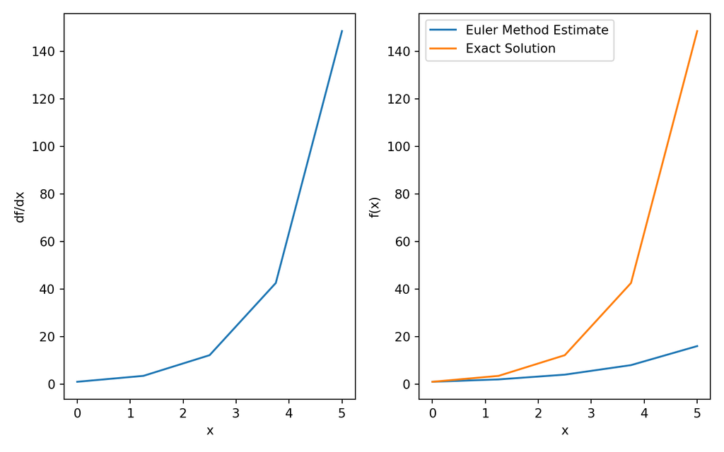

## Euler’s method doesn’t fit very well!?!?

- Euler’s Method is very sensitive to the step size
- The smaller the step size, the better the fit
- Larger step sizes can be okay if the rate of change is small

## Smaller the step size \(\rightarrow\) better fit

- \(\frac{d}{dx}f(x) \Delta x = 0.1\)

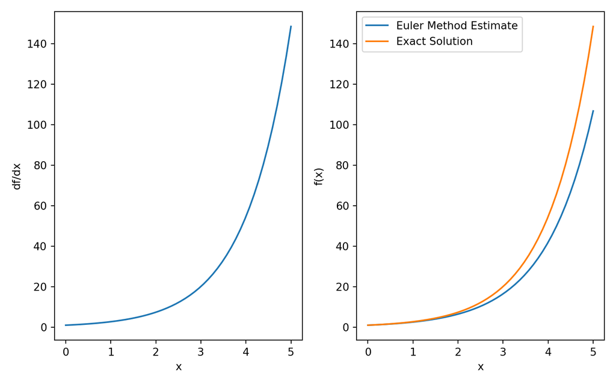

## Larger step size okay if \(\frac{d}{dx}f(x)\) is small

- \(\Delta x = 1, \frac{d}{dx} f(x) = \frac{1}{100} f(x)\)

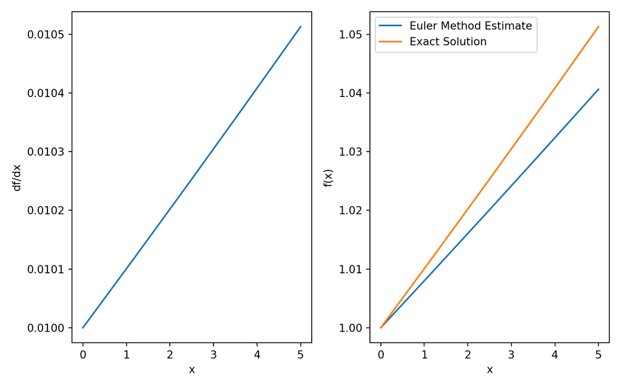

## Choosing a step size

- The smaller the step, the closer the approximation to the true curve.
- However, smaller steps increase computational effort.
- Small steps may not be needed if function changes slowly.
- Finding a balance is key.

## Euler’s Method: Code

- In the following slides we will implement Euler’s method in Python for a simple differential equation.

## Setting up the simulation

We begin by importing the required libraries and specifying the duration and time step.

```python
import numpy as np
import matplotlib.pyplot as plt

# Duration of simulation in ms
T = 1000

# Time step (sample rate) in ms
dt = 0.1
```

## Creating the time vector

We now create a vector of sampled time points.

```python
# Vector of sampled times
t = np.arange(0, T, dt)

# Total number of time steps
N = t.shape[0]
```

## Initializing the state

We define a vector to hold the system’s state over time.

```python
# Vector of state values
x = np.zeros(N)

# Set the initial state
x[0] = 1
```

## Euler’s Method: The loop

We now apply Euler’s method using a `for` loop.

- `dxdt` is the **right-hand side of the differential equation**
- It defines the **rate of change of the system** at each time step

```python
for i in range(1, N):
    dt = t[i] - t[i-1]
    dxdt = x[i-1]  # RHS of dx/dt = x
    x[i] = x[i-1] + dxdt * dt
```

## Visualizing the result

```python
plt.plot(t, x)
plt.xlabel("Time")
plt.ylabel("x(t)")
plt.title("Euler’s Method Approximation")
plt.show()
```

[output not shown]